# Risk Factor Analysis

## Outcome Variable

**Outcome Variable:** haz

## Predictor Variables

**Intervention Variable:** impsan

**Adjustment Set:**

- arm
- sex
- W_mage
- meducyrs
- feducyrs
- hhwealth_quart
- hfoodsec
- W_mhtcm
- W_mwtkg
- W_mbmi
- W_nrooms
- W_nchldlt5
- W_parity
- impfloor
- safeh20
- delta_W_mage
- delta_meducyrs
- delta_feducyrs
- delta_hhwealth_quart
- delta_hfoodsec
- delta_W_mhtcm
- delta_W_mwtkg
- delta_W_mbmi
- delta_W_nrooms
- delta_W_nchldlt5
- delta_W_parity
- delta_impfloor
- delta_safeh20

## Stratifying Variables

The analysis was stratified on these variable(s):

- agecat
- studyid
- country

## Data Summary

| agecat | studyid | country | impsan | n_cell | n |
| --- | --- | --- | --- | --- | --- |
| Birth | ki0047075b-MAL-ED | BANGLADESH | 1 | 179 | 213 |
| Birth | ki0047075b-MAL-ED | BANGLADESH | 0 | 34 | 213 |
| Birth | ki0047075b-MAL-ED | BRAZIL | 1 | 59 | 60 |
| Birth | ki0047075b-MAL-ED | BRAZIL | 0 | 1 | 60 |
| Birth | ki0047075b-MAL-ED | INDIA | 1 | 15 | 40 |
| Birth | ki0047075b-MAL-ED | INDIA | 0 | 25 | 40 |
| Birth | ki0047075b-MAL-ED | NEPAL | 1 | 25 | 26 |
| Birth | ki0047075b-MAL-ED | NEPAL | 0 | 1 | 26 |
| Birth | ki0047075b-MAL-ED | PERU | 1 | 52 | 208 |
| Birth | ki0047075b-MAL-ED | PERU | 0 | 156 | 208 |
| Birth | ki0047075b-MAL-ED | SOUTH AFRICA | 1 | 0 | 95 |
| Birth | ki0047075b-MAL-ED | SOUTH AFRICA | 0 | 95 | 95 |
| Birth | ki0047075b-MAL-ED | TANZANIA, UNITED REPUBLIC OF | 1 | 0 | 118 |
| Birth | ki0047075b-MAL-ED | TANZANIA, UNITED REPUBLIC OF | 0 | 118 | 118 |
| Birth | ki1017093-NIH-Birth | BANGLADESH | 1 | 231 | 608 |
| Birth | ki1017093-NIH-Birth | BANGLADESH | 0 | 377 | 608 |
| Birth | ki1017093b-PROVIDE | BANGLADESH | 1 | 43 | 45 |
| Birth | ki1017093b-PROVIDE | BANGLADESH | 0 | 2 | 45 |
| Birth | ki1017093c-NIH-Crypto | BANGLADESH | 1 | 632 | 721 |
| Birth | ki1017093c-NIH-Crypto | BANGLADESH | 0 | 89 | 721 |
| Birth | ki1114097-CONTENT | PERU | 1 | 1 | 2 |
| Birth | ki1114097-CONTENT | PERU | 0 | 1 | 2 |
| Birth | ki1135781-COHORTS | GUATEMALA | 1 | 45 | 491 |
| Birth | ki1135781-COHORTS | GUATEMALA | 0 | 446 | 491 |
| Birth | ki1135781-COHORTS | INDIA | 1 | 1767 | 4776 |
| Birth | ki1135781-COHORTS | INDIA | 0 | 3009 | 4776 |
| Birth | ki1135781-COHORTS | PHILIPPINES | 1 | 178 | 1191 |
| Birth | ki1135781-COHORTS | PHILIPPINES | 0 | 1013 | 1191 |
| Birth | kiGH5241-JiVitA-3 | BANGLADESH | 1 | 18507 | 26641 |
| Birth | kiGH5241-JiVitA-3 | BANGLADESH | 0 | 8134 | 26641 |

[output cut: 70 more lines]

The following strata were considered:

- agecat: 24 months, studyid: ki0047075b-MAL-ED, country: BANGLADESH
- agecat: 24 months, studyid: ki0047075b-MAL-ED, country: BRAZIL
- agecat: 24 months, studyid: ki0047075b-MAL-ED, country: INDIA
- agecat: 24 months, studyid: ki0047075b-MAL-ED, country: NEPAL
- agecat: 24 months, studyid: ki0047075b-MAL-ED, country: PERU
- agecat: 24 months, studyid: ki0047075b-MAL-ED, country: SOUTH AFRICA
- agecat: 24 months, studyid: ki0047075b-MAL-ED, country: TANZANIA, UNITED REPUBLIC OF
- agecat: 24 months, studyid: ki1017093-NIH-Birth, country: BANGLADESH
- agecat: 24 months, studyid: ki1017093b-PROVIDE, country: BANGLADESH
- agecat: 24 months, studyid: ki1017093c-NIH-Crypto, country: BANGLADESH
- agecat: 24 months, studyid: ki1114097-CONTENT, country: PERU
- agecat: 24 months, studyid: ki1135781-COHORTS, country: GUATEMALA
- agecat: 24 months, studyid: ki1135781-COHORTS, country: INDIA
- agecat: 24 months, studyid: ki1135781-COHORTS, country: PHILIPPINES
- agecat: 24 months, studyid: ki1148112-LCNI-5, country: MALAWI
- agecat: 24 months, studyid: kiGH5241-JiVitA-3, country: BANGLADESH
- agecat: 24 months, studyid: kiGH5241-JiVitA-4, country: BANGLADESH
- agecat: 6 months, studyid: ki0047075b-MAL-ED, country: BANGLADESH
- agecat: 6 months, studyid: ki0047075b-MAL-ED, country: BRAZIL
- agecat: 6 months, studyid: ki0047075b-MAL-ED, country: INDIA
- agecat: 6 months, studyid: ki0047075b-MAL-ED, country: NEPAL
- agecat: 6 months, studyid: ki0047075b-MAL-ED, country: PERU
- agecat: 6 months, studyid: ki0047075b-MAL-ED, country: SOUTH AFRICA
- agecat: 6 months, studyid: ki0047075b-MAL-ED, country: TANZANIA, UNITED REPUBLIC OF
- agecat: 6 months, studyid: ki1017093-NIH-Birth, country: BANGLADESH
- agecat: 6 months, studyid: ki1017093b-PROVIDE, country: BANGLADESH
- agecat: 6 months, studyid: ki1017093c-NIH-Crypto, country: BANGLADESH
- agecat: 6 months, studyid: ki1114097-CONTENT, country: PERU
- agecat: 6 months, studyid: ki1135781-COHORTS, country: GUATEMALA
- agecat: 6 months, studyid: ki1135781-COHORTS, country: INDIA
- agecat: 6 months, studyid: ki1135781-COHORTS, country: PHILIPPINES
- agecat: 6 months, studyid: ki1148112-LCNI-5, country: MALAWI
- agecat: 6 months, studyid: kiGH5241-JiVitA-3, country: BANGLADESH
- agecat: 6 months, studyid: kiGH5241-JiVitA-4, country: BANGLADESH
- agecat: Birth, studyid: ki0047075b-MAL-ED, country: BANGLADESH
- agecat: Birth, studyid: ki0047075b-MAL-ED, country: BRAZIL
- agecat: Birth, studyid: ki0047075b-MAL-ED, country: INDIA
- agecat: Birth, studyid: ki0047075b-MAL-ED, country: NEPAL
- agecat: Birth, studyid: ki0047075b-MAL-ED, country: PERU
- agecat: Birth, studyid: ki0047075b-MAL-ED, country: SOUTH AFRICA
- agecat: Birth, studyid: ki0047075b-MAL-ED, country: TANZANIA, UNITED REPUBLIC OF
- agecat: Birth, studyid: ki1017093-NIH-Birth, country: BANGLADESH
- agecat: Birth, studyid: ki1017093b-PROVIDE, country: BANGLADESH
- agecat: Birth, studyid: ki1017093c-NIH-Crypto, country: BANGLADESH
- agecat: Birth, studyid: ki1114097-CONTENT, country: PERU
- agecat: Birth, studyid: ki1135781-COHORTS, country: GUATEMALA
- agecat: Birth, studyid: ki1135781-COHORTS, country: INDIA
- agecat: Birth, studyid: ki1135781-COHORTS, country: PHILIPPINES
- agecat: Birth, studyid: kiGH5241-JiVitA-3, country: BANGLADESH
- agecat: Birth, studyid: kiGH5241-JiVitA-4, country: BANGLADESH

### Dropped Strata

- agecat: Birth, studyid: ki0047075b-MAL-ED, country: BRAZIL
- agecat: Birth, studyid: ki0047075b-MAL-ED, country: NEPAL
- agecat: Birth, studyid: ki0047075b-MAL-ED, country: SOUTH AFRICA
- agecat: Birth, studyid: ki0047075b-MAL-ED, country: TANZANIA, UNITED REPUBLIC OF
- agecat: Birth, studyid: ki1017093b-PROVIDE, country: BANGLADESH
- agecat: Birth, studyid: ki1114097-CONTENT, country: PERU
- agecat: 6 months, studyid: ki0047075b-MAL-ED, country: BRAZIL
- agecat: 6 months, studyid: ki0047075b-MAL-ED, country: NEPAL
- agecat: 6 months, studyid: ki0047075b-MAL-ED, country: SOUTH AFRICA
- agecat: 6 months, studyid: ki0047075b-MAL-ED, country: TANZANIA, UNITED REPUBLIC OF
- agecat: 6 months, studyid: ki1017093b-PROVIDE, country: BANGLADESH
- agecat: 6 months, studyid: ki1148112-LCNI-5, country: MALAWI
- agecat: 24 months, studyid: ki0047075b-MAL-ED, country: BRAZIL
- agecat: 24 months, studyid: ki0047075b-MAL-ED, country: NEPAL
- agecat: 24 months, studyid: ki0047075b-MAL-ED, country: SOUTH AFRICA
- agecat: 24 months, studyid: ki0047075b-MAL-ED, country: TANZANIA, UNITED REPUBLIC OF
- agecat: 24 months, studyid: ki1017093b-PROVIDE, country: BANGLADESH
- agecat: 24 months, studyid: ki1148112-LCNI-5, country: MALAWI

## Methods Detail

We’re interested in the causal parameters $E[Y_a]$ for all values of $a \in \mathcal{A}$. These parameters represent the mean outcome if, possibly contrary to fact, we intervened to set all units to have $A=a$. Under the randomization and positivity assumptions, these are identified by the statistical parameters $\psi_a=E_W[E_{Y|A,W}(Y|A=a,W)]$. In addition, we’re interested in the mean of $Y$, $E[Y]$ under no intervention (the observed mean). We will estimate these parameters by using SuperLearner to fit the relevant likelihood factors – $E_{Y|A,W}(Y|A=a,W)$ and $p(A=a|W)$, and then updating our likelihood fit using a joint TMLE.

For unadjusted analyses ($W=\{\}$), initial likelihoods were estimated using Lrnr_glm to estimate the simple $E(Y|A)$ and Lrnr_mean to estimate $p(A)$. For adjusted analyses, a small library containing Lrnr_glmnet, Lrnr_xgboost, and Lrnr_mean was used.

Having estimated these parameters, we will then use the delta method to estimate relative risks and attributable risks relative to a prespecified baseline level of $A$.

# Results Detail

## Results Plots

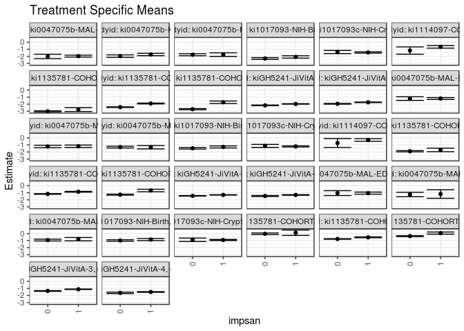

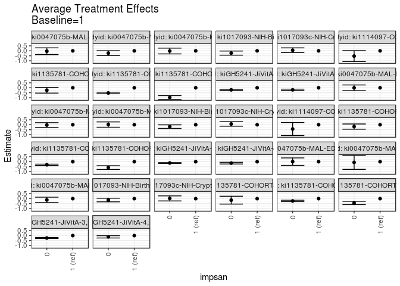

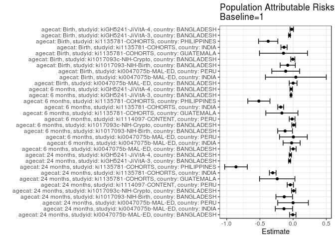

## Results Table

### Parameter: TSM

| agecat | studyid | country | intervention_level | baseline_level | estimate | ci_lower | ci_upper |
| --- | --- | --- | --- | --- | --- | --- | --- |
| Birth | ki0047075b-MAL-ED | BANGLADESH | 1 | NA | -1.0529810 | -1.2036336 | -0.9023285 |
| Birth | ki0047075b-MAL-ED | BANGLADESH | 0 | NA | -1.0469703 | -1.3897460 | -0.7041946 |
| Birth | ki0047075b-MAL-ED | INDIA | 1 | NA | -1.1786483 | -1.7827723 | -0.5745243 |
| Birth | ki0047075b-MAL-ED | INDIA | 0 | NA | -1.2497247 | -1.5654806 | -0.9339687 |
| Birth | ki0047075b-MAL-ED | PERU | 1 | NA | -0.8015759 | -1.0397446 | -0.5634072 |
| Birth | ki0047075b-MAL-ED | PERU | 0 | NA | -0.9274493 | -1.0600080 | -0.7948906 |
| Birth | ki1017093-NIH-Birth | BANGLADESH | 1 | NA | -0.8497583 | -1.0003698 | -0.6991469 |
| Birth | ki1017093-NIH-Birth | BANGLADESH | 0 | NA | -0.9859161 | -1.0937749 | -0.8780573 |
| Birth | ki1017093c-NIH-Crypto | BANGLADESH | 1 | NA | -0.9088547 | -0.9837432 | -0.8339661 |
| Birth | ki1017093c-NIH-Crypto | BANGLADESH | 0 | NA | -0.8836200 | -1.1269610 | -0.6402789 |
| Birth | ki1135781-COHORTS | GUATEMALA | 1 | NA | 0.1176904 | -0.2612285 | 0.4966094 |
| Birth | ki1135781-COHORTS | GUATEMALA | 0 | NA | -0.0333777 | -0.1471577 | 0.0804023 |
| Birth | ki1135781-COHORTS | INDIA | 1 | NA | -0.5405766 | -0.5973063 | -0.4838469 |
| Birth | ki1135781-COHORTS | INDIA | 0 | NA | -0.7683241 | -0.8110030 | -0.7256451 |
| Birth | ki1135781-COHORTS | PHILIPPINES | 1 | NA | 0.0618386 | -0.0909954 | 0.2146727 |
| Birth | ki1135781-COHORTS | PHILIPPINES | 0 | NA | -0.3696314 | -0.4379787 | -0.3012841 |
| Birth | kiGH5241-JiVitA-3 | BANGLADESH | 1 | NA | -1.1192130 | -1.1516957 | -1.0867302 |
| Birth | kiGH5241-JiVitA-3 | BANGLADESH | 0 | NA | -1.3595004 | -1.4071539 | -1.3118470 |
| Birth | kiGH5241-JiVitA-4 | BANGLADESH | 1 | NA | -1.5027035 | -1.5588523 | -1.4465548 |
| Birth | kiGH5241-JiVitA-4 | BANGLADESH | 0 | NA | -1.6281765 | -1.7282366 | -1.5281163 |
| 6 months | ki0047075b-MAL-ED | BANGLADESH | 1 | NA | -1.2028108 | -1.3344576 | -1.0711640 |
| 6 months | ki0047075b-MAL-ED | BANGLADESH | 0 | NA | -1.2087954 | -1.4679234 | -0.9496675 |
| 6 months | ki0047075b-MAL-ED | INDIA | 1 | NA | -1.1861467 | -1.3534980 | -1.0187953 |
| 6 months | ki0047075b-MAL-ED | INDIA | 0 | NA | -1.2180623 | -1.3902816 | -1.0458430 |
| 6 months | ki0047075b-MAL-ED | PERU | 1 | NA | -1.3263242 | -1.5629159 | -1.0897325 |
| 6 months | ki0047075b-MAL-ED | PERU | 0 | NA | -1.3068977 | -1.4323661 | -1.1814294 |
| 6 months | ki1017093-NIH-Birth | BANGLADESH | 1 | NA | -1.2858956 | -1.4277741 | -1.1440171 |
| 6 months | ki1017093-NIH-Birth | BANGLADESH | 0 | NA | -1.4743830 | -1.5858794 | -1.3628865 |
| 6 months | ki1017093c-NIH-Crypto | BANGLADESH | 1 | NA | -1.2126178 | -1.2887911 | -1.1364445 |
| 6 months | ki1017093c-NIH-Crypto | BANGLADESH | 0 | NA | -1.1333338 | -1.3472539 | -0.9194137 |
| 6 months | ki1114097-CONTENT | PERU | 1 | NA | -0.2988484 | -0.4785752 | -0.1191216 |
| 6 months | ki1114097-CONTENT | PERU | 0 | NA | -0.7281000 | -1.3591037 | -0.0970963 |
| 6 months | ki1135781-COHORTS | GUATEMALA | 1 | NA | -1.7095014 | -1.9574450 | -1.4615578 |
| 6 months | ki1135781-COHORTS | GUATEMALA | 0 | NA | -1.8944807 | -1.9818438 | -1.8071175 |
| 6 months | ki1135781-COHORTS | INDIA | 1 | NA | -0.8544120 | -0.9078397 | -0.8009843 |
| 6 months | ki1135781-COHORTS | INDIA | 0 | NA | -1.1669034 | -1.2087320 | -1.1250748 |
| 6 months | ki1135781-COHORTS | PHILIPPINES | 1 | NA | -0.6786255 | -0.8544107 | -0.5028404 |
| 6 months | ki1135781-COHORTS | PHILIPPINES | 0 | NA | -1.2700882 | -1.3405938 | -1.1995826 |
| 6 months | kiGH5241-JiVitA-3 | BANGLADESH | 1 | NA | -1.3039120 | -1.3294031 | -1.2784208 |
| 6 months | kiGH5241-JiVitA-3 | BANGLADESH | 0 | NA | -1.4332800 | -1.4718645 | -1.3946954 |
| 6 months | kiGH5241-JiVitA-4 | BANGLADESH | 1 | NA | -1.3148230 | -1.3566157 | -1.2730304 |
| 6 months | kiGH5241-JiVitA-4 | BANGLADESH | 0 | NA | -1.4582914 | -1.5346142 | -1.3819685 |
| 24 months | ki0047075b-MAL-ED | BANGLADESH | 1 | NA | -1.9736653 | -2.1132138 | -1.8341169 |
| 24 months | ki0047075b-MAL-ED | BANGLADESH | 0 | NA | -2.0112121 | -2.3201727 | -1.7022515 |
| 24 months | ki0047075b-MAL-ED | INDIA | 1 | NA | -1.7385499 | -1.9059880 | -1.5711119 |
| 24 months | ki0047075b-MAL-ED | INDIA | 0 | NA | -1.9697216 | -2.1476089 | -1.7918343 |
| 24 months | ki0047075b-MAL-ED | PERU | 1 | NA | -1.7547800 | -2.0114045 | -1.4981555 |
| 24 months | ki0047075b-MAL-ED | PERU | 0 | NA | -1.7735948 | -1.9161005 | -1.6310891 |
| 24 months | ki1017093-NIH-Birth | BANGLADESH | 1 | NA | -2.0850920 | -2.2541313 | -1.9160526 |
| 24 months | ki1017093-NIH-Birth | BANGLADESH | 0 | NA | -2.3120866 | -2.4360846 | -2.1880886 |
| 24 months | ki1017093c-NIH-Crypto | BANGLADESH | 1 | NA | -1.4497900 | -1.5418492 | -1.3577308 |
| 24 months | ki1017093c-NIH-Crypto | BANGLADESH | 0 | NA | -1.3907526 | -1.6103475 | -1.1711576 |
| 24 months | ki1114097-CONTENT | PERU | 1 | NA | -0.6539478 | -0.8337097 | -0.4741858 |
| 24 months | ki1114097-CONTENT | PERU | 0 | NA | -1.1819891 | -1.6974146 | -0.6665636 |
| 24 months | ki1135781-COHORTS | GUATEMALA | 1 | NA | -2.7658306 | -3.0402262 | -2.4914350 |
| 24 months | ki1135781-COHORTS | GUATEMALA | 0 | NA | -3.0153648 | -3.0891530 | -2.9415765 |
| 24 months | ki1135781-COHORTS | INDIA | 1 | NA | -1.9054626 | -1.9668476 | -1.8440776 |
| 24 months | ki1135781-COHORTS | INDIA | 0 | NA | -2.4247516 | -2.4750672 | -2.3744359 |
| 24 months | ki1135781-COHORTS | PHILIPPINES | 1 | NA | -1.7334274 | -1.9091397 | -1.5577151 |
| 24 months | ki1135781-COHORTS | PHILIPPINES | 0 | NA | -2.7122093 | -2.7841176 | -2.6403011 |
| 24 months | kiGH5241-JiVitA-3 | BANGLADESH | 1 | NA | -1.9670929 | -1.9983665 | -1.9358192 |
| 24 months | kiGH5241-JiVitA-3 | BANGLADESH | 0 | NA | -2.1739067 | -2.2213459 | -2.1264675 |
| 24 months | kiGH5241-JiVitA-4 | BANGLADESH | 1 | NA | -1.7381922 | -1.7789549 | -1.6974296 |
| 24 months | kiGH5241-JiVitA-4 | BANGLADESH | 0 | NA | -1.9464255 | -2.0067621 | -1.8860889 |

### Parameter: E(Y)

| agecat | studyid | country | intervention_level | baseline_level | estimate | ci_lower | ci_upper |
| --- | --- | --- | --- | --- | --- | --- | --- |
| Birth | ki0047075b-MAL-ED | BANGLADESH | NA | NA | -1.0530516 | -1.1896058 | -0.9164975 |
| Birth | ki0047075b-MAL-ED | INDIA | NA | NA | -1.1375000 | -1.4325178 | -0.8424822 |
| Birth | ki0047075b-MAL-ED | PERU | NA | NA | -0.9131731 | -1.0331160 | -0.7932301 |
| Birth | ki1017093-NIH-Birth | BANGLADESH | NA | NA | -0.9310197 | -1.0197391 | -0.8423003 |
| Birth | ki1017093c-NIH-Crypto | BANGLADESH | NA | NA | -0.9131068 | -0.9851939 | -0.8410197 |
| Birth | ki1135781-COHORTS | GUATEMALA | NA | NA | -0.0275356 | -0.1359303 | 0.0808590 |
| Birth | ki1135781-COHORTS | INDIA | NA | NA | -0.6777115 | -0.7106054 | -0.6448175 |
| Birth | ki1135781-COHORTS | PHILIPPINES | NA | NA | -0.3137364 | -0.3764483 | -0.2510244 |
| Birth | kiGH5241-JiVitA-3 | BANGLADESH | NA | NA | -1.1730603 | -1.2011221 | -1.1449986 |
| Birth | kiGH5241-JiVitA-4 | BANGLADESH | NA | NA | -1.5236135 | -1.5727559 | -1.4744711 |
| 6 months | ki0047075b-MAL-ED | BANGLADESH | NA | NA | -1.2031806 | -1.3209873 | -1.0853738 |
| 6 months | ki0047075b-MAL-ED | INDIA | NA | NA | -1.2085694 | -1.3282177 | -1.0889210 |
| 6 months | ki0047075b-MAL-ED | PERU | NA | NA | -1.3223764 | -1.4323641 | -1.2123887 |
| 6 months | ki1017093-NIH-Birth | BANGLADESH | NA | NA | -1.4073821 | -1.4960598 | -1.3187043 |
| 6 months | ki1017093c-NIH-Crypto | BANGLADESH | NA | NA | -1.2031037 | -1.2749632 | -1.1312442 |
| 6 months | ki1114097-CONTENT | PERU | NA | NA | -0.3139217 | -0.4868486 | -0.1409948 |
| 6 months | ki1135781-COHORTS | GUATEMALA | NA | NA | -1.8789210 | -1.9609921 | -1.7968498 |
| 6 months | ki1135781-COHORTS | INDIA | NA | NA | -1.0414424 | -1.0741113 | -1.0087734 |
| 6 months | ki1135781-COHORTS | PHILIPPINES | NA | NA | -1.1942936 | -1.2608624 | -1.1277248 |
| 6 months | kiGH5241-JiVitA-3 | BANGLADESH | NA | NA | -1.3359778 | -1.3590491 | -1.3129065 |
| 6 months | kiGH5241-JiVitA-4 | BANGLADESH | NA | NA | -1.3440477 | -1.3813060 | -1.3067894 |
| 24 months | ki0047075b-MAL-ED | BANGLADESH | NA | NA | -1.9789151 | -2.1055330 | -1.8522972 |
| 24 months | ki0047075b-MAL-ED | INDIA | NA | NA | -1.8766000 | -2.0020012 | -1.7511988 |
| 24 months | ki0047075b-MAL-ED | PERU | NA | NA | -1.7559184 | -1.8781773 | -1.6336595 |
| 24 months | ki1017093-NIH-Birth | BANGLADESH | NA | NA | -2.2190579 | -2.3217459 | -2.1163699 |
| 24 months | ki1017093c-NIH-Crypto | BANGLADESH | NA | NA | -1.4417097 | -1.5263855 | -1.3570340 |
| 24 months | ki1114097-CONTENT | PERU | NA | NA | -0.6962195 | -0.8674103 | -0.5250287 |
| 24 months | ki1135781-COHORTS | GUATEMALA | NA | NA | -3.0050840 | -3.0758338 | -2.9343342 |
| 24 months | ki1135781-COHORTS | INDIA | NA | NA | -2.2126633 | -2.2518337 | -2.1734929 |
| 24 months | ki1135781-COHORTS | PHILIPPINES | NA | NA | -2.5937576 | -2.6629996 | -2.5245156 |
| 24 months | kiGH5241-JiVitA-3 | BANGLADESH | NA | NA | -2.0196341 | -2.0472667 | -1.9920015 |
| 24 months | kiGH5241-JiVitA-4 | BANGLADESH | NA | NA | -1.7803708 | -1.8158650 | -1.7448765 |

### Parameter: ATE

| agecat | studyid | country | intervention_level | baseline_level | estimate | ci_lower | ci_upper |
| --- | --- | --- | --- | --- | --- | --- | --- |
| Birth | ki0047075b-MAL-ED | BANGLADESH | 1 | 1 | 0.0000000 | 0.0000000 | 0.0000000 |
| Birth | ki0047075b-MAL-ED | BANGLADESH | 0 | 1 | 0.0060108 | -0.3690164 | 0.3810379 |
| Birth | ki0047075b-MAL-ED | INDIA | 1 | 1 | 0.0000000 | 0.0000000 | 0.0000000 |
| Birth | ki0047075b-MAL-ED | INDIA | 0 | 1 | -0.0710764 | -0.7714031 | 0.6292503 |
| Birth | ki0047075b-MAL-ED | PERU | 1 | 1 | 0.0000000 | 0.0000000 | 0.0000000 |
| Birth | ki0047075b-MAL-ED | PERU | 0 | 1 | -0.1258734 | -0.3980266 | 0.1462798 |
| Birth | ki1017093-NIH-Birth | BANGLADESH | 1 | 1 | 0.0000000 | 0.0000000 | 0.0000000 |
| Birth | ki1017093-NIH-Birth | BANGLADESH | 0 | 1 | -0.1361577 | -0.3201834 | 0.0478679 |
| Birth | ki1017093c-NIH-Crypto | BANGLADESH | 1 | 1 | 0.0000000 | 0.0000000 | 0.0000000 |
| Birth | ki1017093c-NIH-Crypto | BANGLADESH | 0 | 1 | 0.0252347 | -0.2287563 | 0.2792256 |
| Birth | ki1135781-COHORTS | GUATEMALA | 1 | 1 | 0.0000000 | 0.0000000 | 0.0000000 |
| Birth | ki1135781-COHORTS | GUATEMALA | 0 | 1 | -0.1510681 | -0.5463851 | 0.2442489 |
| Birth | ki1135781-COHORTS | INDIA | 1 | 1 | 0.0000000 | 0.0000000 | 0.0000000 |
| Birth | ki1135781-COHORTS | INDIA | 0 | 1 | -0.2277475 | -0.2984552 | -0.1570397 |
| Birth | ki1135781-COHORTS | PHILIPPINES | 1 | 1 | 0.0000000 | 0.0000000 | 0.0000000 |
| Birth | ki1135781-COHORTS | PHILIPPINES | 0 | 1 | -0.4314700 | -0.5984527 | -0.2644873 |
| Birth | kiGH5241-JiVitA-3 | BANGLADESH | 1 | 1 | 0.0000000 | 0.0000000 | 0.0000000 |
| Birth | kiGH5241-JiVitA-3 | BANGLADESH | 0 | 1 | -0.2402875 | -0.2944818 | -0.1860931 |
| Birth | kiGH5241-JiVitA-4 | BANGLADESH | 1 | 1 | 0.0000000 | 0.0000000 | 0.0000000 |
| Birth | kiGH5241-JiVitA-4 | BANGLADESH | 0 | 1 | -0.1254730 | -0.2388464 | -0.0120995 |
| 6 months | ki0047075b-MAL-ED | BANGLADESH | 1 | 1 | 0.0000000 | 0.0000000 | 0.0000000 |
| 6 months | ki0047075b-MAL-ED | BANGLADESH | 0 | 1 | -0.0059847 | -0.2970655 | 0.2850962 |
| 6 months | ki0047075b-MAL-ED | INDIA | 1 | 1 | 0.0000000 | 0.0000000 | 0.0000000 |
| 6 months | ki0047075b-MAL-ED | INDIA | 0 | 1 | -0.0319156 | -0.2723090 | 0.2084778 |
| 6 months | ki0047075b-MAL-ED | PERU | 1 | 1 | 0.0000000 | 0.0000000 | 0.0000000 |
| 6 months | ki0047075b-MAL-ED | PERU | 0 | 1 | 0.0194265 | -0.2472277 | 0.2860806 |
| 6 months | ki1017093-NIH-Birth | BANGLADESH | 1 | 1 | 0.0000000 | 0.0000000 | 0.0000000 |
| 6 months | ki1017093-NIH-Birth | BANGLADESH | 0 | 1 | -0.1884874 | -0.3673956 | -0.0095791 |
| 6 months | ki1017093c-NIH-Crypto | BANGLADESH | 1 | 1 | 0.0000000 | 0.0000000 | 0.0000000 |
| 6 months | ki1017093c-NIH-Crypto | BANGLADESH | 0 | 1 | 0.0792840 | -0.1478231 | 0.3063911 |
| 6 months | ki1114097-CONTENT | PERU | 1 | 1 | 0.0000000 | 0.0000000 | 0.0000000 |
| 6 months | ki1114097-CONTENT | PERU | 0 | 1 | -0.4292516 | -1.0854448 | 0.2269417 |
| 6 months | ki1135781-COHORTS | GUATEMALA | 1 | 1 | 0.0000000 | 0.0000000 | 0.0000000 |
| 6 months | ki1135781-COHORTS | GUATEMALA | 0 | 1 | -0.1849792 | -0.4480105 | 0.0780521 |
| 6 months | ki1135781-COHORTS | INDIA | 1 | 1 | 0.0000000 | 0.0000000 | 0.0000000 |
| 6 months | ki1135781-COHORTS | INDIA | 0 | 1 | -0.3124914 | -0.3796168 | -0.2453660 |
| 6 months | ki1135781-COHORTS | PHILIPPINES | 1 | 1 | 0.0000000 | 0.0000000 | 0.0000000 |
| 6 months | ki1135781-COHORTS | PHILIPPINES | 0 | 1 | -0.5914627 | -0.7811793 | -0.4017461 |
| 6 months | kiGH5241-JiVitA-3 | BANGLADESH | 1 | 1 | 0.0000000 | 0.0000000 | 0.0000000 |
| 6 months | kiGH5241-JiVitA-3 | BANGLADESH | 0 | 1 | -0.1293680 | -0.1692447 | -0.0894913 |
| 6 months | kiGH5241-JiVitA-4 | BANGLADESH | 1 | 1 | 0.0000000 | 0.0000000 | 0.0000000 |
| 6 months | kiGH5241-JiVitA-4 | BANGLADESH | 0 | 1 | -0.1434683 | -0.2292452 | -0.0576915 |
| 24 months | ki0047075b-MAL-ED | BANGLADESH | 1 | 1 | 0.0000000 | 0.0000000 | 0.0000000 |
| 24 months | ki0047075b-MAL-ED | BANGLADESH | 0 | 1 | -0.0375468 | -0.3765980 | 0.3015044 |
| 24 months | ki0047075b-MAL-ED | INDIA | 1 | 1 | 0.0000000 | 0.0000000 | 0.0000000 |
| 24 months | ki0047075b-MAL-ED | INDIA | 0 | 1 | -0.2311717 | -0.4711995 | 0.0088561 |
| 24 months | ki0047075b-MAL-ED | PERU | 1 | 1 | 0.0000000 | 0.0000000 | 0.0000000 |
| 24 months | ki0047075b-MAL-ED | PERU | 0 | 1 | -0.0188148 | -0.3117041 | 0.2740745 |
| 24 months | ki1017093-NIH-Birth | BANGLADESH | 1 | 1 | 0.0000000 | 0.0000000 | 0.0000000 |
| 24 months | ki1017093-NIH-Birth | BANGLADESH | 0 | 1 | -0.2269946 | -0.4329183 | -0.0210709 |
| 24 months | ki1017093c-NIH-Crypto | BANGLADESH | 1 | 1 | 0.0000000 | 0.0000000 | 0.0000000 |
| 24 months | ki1017093c-NIH-Crypto | BANGLADESH | 0 | 1 | 0.0590374 | -0.1797301 | 0.2978050 |
| 24 months | ki1114097-CONTENT | PERU | 1 | 1 | 0.0000000 | 0.0000000 | 0.0000000 |
| 24 months | ki1114097-CONTENT | PERU | 0 | 1 | -0.5280413 | -1.0743220 | 0.0182393 |
| 24 months | ki1135781-COHORTS | GUATEMALA | 1 | 1 | 0.0000000 | 0.0000000 | 0.0000000 |
| 24 months | ki1135781-COHORTS | GUATEMALA | 0 | 1 | -0.2495342 | -0.5332671 | 0.0341987 |
| 24 months | ki1135781-COHORTS | INDIA | 1 | 1 | 0.0000000 | 0.0000000 | 0.0000000 |
| 24 months | ki1135781-COHORTS | INDIA | 0 | 1 | -0.5192890 | -0.5986121 | -0.4399658 |
| 24 months | ki1135781-COHORTS | PHILIPPINES | 1 | 1 | 0.0000000 | 0.0000000 | 0.0000000 |
| 24 months | ki1135781-COHORTS | PHILIPPINES | 0 | 1 | -0.9787819 | -1.1691594 | -0.7884044 |
| 24 months | kiGH5241-JiVitA-3 | BANGLADESH | 1 | 1 | 0.0000000 | 0.0000000 | 0.0000000 |
| 24 months | kiGH5241-JiVitA-3 | BANGLADESH | 0 | 1 | -0.2068138 | -0.2587266 | -0.1549010 |
| 24 months | kiGH5241-JiVitA-4 | BANGLADESH | 1 | 1 | 0.0000000 | 0.0000000 | 0.0000000 |
| 24 months | kiGH5241-JiVitA-4 | BANGLADESH | 0 | 1 | -0.2082332 | -0.2794178 | -0.1370487 |

### Parameter: PAR

| agecat | studyid | country | intervention_level | baseline_level | estimate | ci_lower | ci_upper |
| --- | --- | --- | --- | --- | --- | --- | --- |
| Birth | ki0047075b-MAL-ED | BANGLADESH | 1 | NA | -0.0000706 | -0.0584028 | 0.0582616 |
| Birth | ki0047075b-MAL-ED | INDIA | 1 | NA | 0.0411483 | -0.4171259 | 0.4994224 |
| Birth | ki0047075b-MAL-ED | PERU | 1 | NA | -0.1115972 | -0.3211012 | 0.0979068 |
| Birth | ki1017093-NIH-Birth | BANGLADESH | 1 | NA | -0.0812614 | -0.1954344 | 0.0329116 |
| Birth | ki1017093c-NIH-Crypto | BANGLADESH | 1 | NA | -0.0042521 | -0.0348062 | 0.0263019 |
| Birth | ki1135781-COHORTS | GUATEMALA | 1 | NA | -0.1452261 | -0.5068383 | 0.2163861 |
| Birth | ki1135781-COHORTS | INDIA | 1 | NA | -0.1371349 | -0.1836632 | -0.0906065 |
| Birth | ki1135781-COHORTS | PHILIPPINES | 1 | NA | -0.3755750 | -0.5208776 | -0.2302724 |
| Birth | kiGH5241-JiVitA-3 | BANGLADESH | 1 | NA | -0.0538473 | -0.0668968 | -0.0407979 |
| Birth | kiGH5241-JiVitA-4 | BANGLADESH | 1 | NA | -0.0209100 | -0.0466560 | 0.0048361 |
| 6 months | ki0047075b-MAL-ED | BANGLADESH | 1 | NA | -0.0003698 | -0.0456083 | 0.0448687 |
| 6 months | ki0047075b-MAL-ED | INDIA | 1 | NA | -0.0224227 | -0.1510596 | 0.1062142 |
| 6 months | ki0047075b-MAL-ED | PERU | 1 | NA | 0.0039478 | -0.2055111 | 0.2134067 |
| 6 months | ki1017093-NIH-Birth | BANGLADESH | 1 | NA | -0.1214865 | -0.2327703 | -0.0102027 |
| 6 months | ki1017093c-NIH-Crypto | BANGLADESH | 1 | NA | 0.0095141 | -0.0192723 | 0.0383005 |
| 6 months | ki1114097-CONTENT | PERU | 1 | NA | -0.0150733 | -0.0582488 | 0.0281023 |
| 6 months | ki1135781-COHORTS | GUATEMALA | 1 | NA | -0.1694196 | -0.4112373 | 0.0723982 |
| 6 months | ki1135781-COHORTS | INDIA | 1 | NA | -0.1870304 | -0.2310509 | -0.1430098 |
| 6 months | ki1135781-COHORTS | PHILIPPINES | 1 | NA | -0.5156681 | -0.6825378 | -0.3487985 |
| 6 months | kiGH5241-JiVitA-3 | BANGLADESH | 1 | NA | -0.0320658 | -0.0429223 | -0.0212093 |
| 6 months | kiGH5241-JiVitA-4 | BANGLADESH | 1 | NA | -0.0292246 | -0.0482771 | -0.0101722 |
| 24 months | ki0047075b-MAL-ED | BANGLADESH | 1 | NA | -0.0052498 | -0.0531176 | 0.0426181 |
| 24 months | ki0047075b-MAL-ED | INDIA | 1 | NA | -0.1380501 | -0.2685409 | -0.0075593 |
| 24 months | ki0047075b-MAL-ED | PERU | 1 | NA | -0.0011384 | -0.2318490 | 0.2295722 |
| 24 months | ki1017093-NIH-Birth | BANGLADESH | 1 | NA | -0.1339659 | -0.2590623 | -0.0088695 |
| 24 months | ki1017093c-NIH-Crypto | BANGLADESH | 1 | NA | 0.0080803 | -0.0241789 | 0.0403394 |
| 24 months | ki1114097-CONTENT | PERU | 1 | NA | -0.0422717 | -0.0892374 | 0.0046940 |
| 24 months | ki1135781-COHORTS | GUATEMALA | 1 | NA | -0.2392534 | -0.5055993 | 0.0270925 |
| 24 months | ki1135781-COHORTS | INDIA | 1 | NA | -0.3072007 | -0.3571021 | -0.2572992 |
| 24 months | ki1135781-COHORTS | PHILIPPINES | 1 | NA | -0.8603302 | -1.0306144 | -0.6900459 |
| 24 months | kiGH5241-JiVitA-3 | BANGLADESH | 1 | NA | -0.0525413 | -0.0677417 | -0.0373408 |
| 24 months | kiGH5241-JiVitA-4 | BANGLADESH | 1 | NA | -0.0421785 | -0.0586281 | -0.0257290 |